# Parallel functional testing identifies enhancers active in early postnatal mouse brain. miniMPRA experiment

Jason T. Lambert, Linda Su-Feher, Karol Cichewicz, Tracy L. Warren, Iva Zdilar, Yurong Wang, Kenneth J. Lim, Jessica Haigh, Sarah J. Morse, Cesar P. Canales, Tyler W. Stradleigh, Erika Castillo, Viktoria Haghani, Spencer Moss, Hannah Parolini, Diana Quintero, Diwash Shrestha, Daniel Vogt, Leah C. Byrne, Alex S. Nord. 2021: [Parallel functional testing identifies enhancers active in early postnatal mouse brain](https://www.biorxiv.org/content/10.1101/2021.01.15.426772v3)

Data analysis by: Karol Cichewicz, email, [LinkedIn](https://www.linkedin.com/in/karol-cichewicz/), [Follow me on Twitter](https://twitter.com/karolcichewicz) Linda Su-Feher, Yurong Wang, [Nord Neurogenomics Lab website](https://nordlab.faculty.ucdavis.edu/), [Follow us on Twitter](https://twitter.com/NordLabUCD) Raw data available at GSE172058

Abstract

Enhancers are cis-regulatory elements that play critical regulatory roles in modulating developmental transcription programs and driving cell-type specific and context-dependent gene expression in the brain. The development of massively parallel reporter assays (MPRAs) has enabled high-throughput functional screening of candidate DNA sequences for enhancer activity. Tissue-specific screening of in vivo enhancer function at scale has the potential to greatly expand our understanding of the role of non-coding sequences in development, evolution, and disease. Here, we adapted a self-transcribing regulatory element MPRA strategy for delivery to early postnatal mouse brain via recombinant adeno-associated virus (rAAV). We identified and validated putative enhancers capable of driving reporter gene expression in mouse forebrain, including regulatory elements within an intronic CACNA1C linkage disequilibrium block associated with risk in neuropsychiatric disorder genetic studies. Paired screening and single enhancer in vivo functional testing, as we show here, represents a powerful approach towards characterizing regulatory activity of enhancers and understanding how enhancer sequences organize gene expression in the brain.

# 1. Dataset info

- 16 mouse amplicons with human orthologs. The host organism is mouse too.
- Reads are aligned to GRCm38, for consistency with GRCh38 in STAR408 library
- Amplicon coordinates need to be translated from mm9 and/or in silico PCR. Linda performed LiftOver conversion and saved the results as miniMPRA_mm10_coords.bed
- Shell scripts were combined into bwa_mem_pipeline.sh, which is saved as a separate file. It needs a bit of refinement but it’s a decent draft of simple read processing pipeline.
- 500 bp band count files - Do not analyze. It’s just a spurious samples.

```r
# Global R markdown code chunk options
knitr::opts_chunk$set(message=FALSE,
                      warning = FALSE,
                      error=FALSE,
                      echo=TRUE,
                      cache=FALSE,
                      fig.width = 7, fig.height = 6,
                      fig.align = 'left')
```

# 2. Shell scripts

### Picard tools - dictionary creation

```bash
# Run in an interactive session. Took 0.30 min
srun -t 05:30:00 -c 8 -n 1 --mem 8000 --pty /bin/bash

java -Xmx8g -jar /share/nordlab/users/kcichewicz/bin/picard.jar CreateSequenceDictionary \
REFERENCE=/share/nordlab/genomes/Mus_musculus/Ensembl/GRCm38/Sequence/WholeGenomeFasta/Mus_musculus.GRCm38.dna.primary_assembly.fa \
OUTPUT=/share/nordlab/users/kcichewicz/Reference/Picard_Sequence_Dictionaries/GRCm38_picard.dict/
```

### BWA index creation

```bash
# Run in an interactive session. Took about 1 h (??)

/share/nordlab/users/kcichewicz/bin/bwa-0.7.17/bwa index -a bwtsw \
/share/nordlab/genomes/Mus_musculus/Ensembl/GRCm38/Sequence/WholeGenomeFasta/Mus_musculus.GRCm38.dna.primary_assembly.fa

#-a STR Algorithm for constructing BWT index. Available options are:
#is IS linear-time algorithm for constructing suffix array. It requires 5.37N memory where N is the size of the #database. IS is moderately fast, but does not work with database larger than 2GB. IS is the default algorithm due #to its simplicity. The current codes for IS algorithm are reimplemented by Yuta Mori.

#bwtsw  Algorithm implemented in BWT-SW. This method works with the whole human genome.
```

### fastQC quality control

```bash
#!/bin/sh
#SBATCH --job-name=fastq
#SBATCH --time=02:00:00
#SBATCH --mem=16000
#SBATCH --ntasks=8

/share/nordlab/users/kcichewicz/bin/FastQC/fastqc \
--threads 8 \
--outdir /share/nordlab/users/kcichewicz/miniMPRA/fastQC_out \
/share/nordlab/rawdata/miniMPRA/*fastq
```

### Smart read trimming with NGmerge

```bash
#NGmerge was run as follows:

#!/bin/sh
#SBATCH --job-name=NG_trim
#SBATCH --time=03:00:00
#SBATCH --mem=8000
#SBATCH --ntasks=4

current_sample=$1
input_dir=/share/nordlab/rawdata/miniMPRA/
output_dir=/share/nordlab/users/kcichewicz/miniMPRA/trimmed_fastq/

/share/nordlab/users/kcichewicz/bin/NGmerge-master/NGmerge \
-a \
-v \
-u 41 \
-n 4 \
-1 $input_dir/"$current_sample"_L001_R1_001.fastq \
-2 $input_dir/"$current_sample"_L001_R2_001.fastq \
-o $output_dir/"$current_sample"


for sample in STARR-l-1kb-150311_S5 STARR-l-500bp-150311_S6 STARR-s1-1kb-150311_S1 STARR-s1-500bp-150311_S7 STARR-s2-1kb-150311_S2 STARR-s3-1kb-150311_S3 STARR-s4-1kb-150311_S4
do
  sbatch NG_merge.sh $sample
done


STARR-l-1kb-150311_S5
STARR-l-500bp-150311_S6
STARR-s1-1kb-150311_S1
STARR-s1-500bp-150311_S7
STARR-s2-1kb-150311_S2
STARR-s3-1kb-150311_S3
STARR-s4-1kb-150311_S4
```

### Alignment

```bash
#!/bin/sh
#SBATCH --job-name=bwa
#SBATCH --time=03:00:00
#SBATCH --mem=32000
#SBATCH --ntasks=12

current_sample=$1

reads=/share/nordlab/users/kcichewicz/miniMPRA/trimmed_fastq/
out_dir=/share/nordlab/users/kcichewicz/miniMPRA/sam_files
genome=/share/nordlab/genomes/Mus_musculus/Ensembl/GRCm38/Sequence/WholeGenomeFasta/Mus_musculus.GRCm38.dna.primary_assembly.fa


/share/nordlab/users/kcichewicz/bin/bwa-0.7.17/bwa mem \
-t 12 \
-M \
$genome \
$reads/"$current_sample"_1.fastq \
$reads/"$current_sample"_2.fastq \
> $out_dir/$current_sample.sam

for sample in STARR-l-1kb-150311_S5 STARR-l-500bp-150311_S6 STARR-s1-1kb-150311_S1 STARR-s1-500bp-150311_S7 STARR-s2-1kb-150311_S2 STARR-s3-1kb-150311_S3 STARR-s4-1kb-150311_S4
do
 sbatch bwa_mem.sh $sample
done
```

### Converting sam to bam files with picard tools

```bash
#!/bin/sh
#SBATCH --job-name=sam_to_bam
#SBATCH --time=02:00:00
#SBATCH --mem=8000
#SBATCH --ntasks=1

current_sample=$1
java -Xmx8g -jar /share/nordlab/users/kcichewicz/bin/picard.jar SortSam \
INPUT= /share/nordlab/users/kcichewicz/miniMPRA/$current_sample.sam \
OUTPUT= /share/nordlab/users/kcichewicz/miniMPRA/sorted_bam/$current_sample.bam \
SORT_ORDER=coordinate

for sample in STARR-l-1kb-150311_S5 STARR-l-500bp-150311_S6 STARR-s1-1kb-150311_S1 STARR-s1-500bp-150311_S7 STARR-s2-1kb-150311_S2 STARR-s3-1kb-150311_S3 STARR-s4-1kb-150311_S4
do
 sbatch sam_to_bam.sh $sample
done
```

### Duplicates removal

```bash
#!/bin/sh
#SBATCH --job-name=bwa
#SBATCH --time=03:00:00
#SBATCH --mem=8000
#SBATCH --ntasks=1


java -Xmx4g -jar /share/nordlab/users/kcichewicz/bin/picard.jar BuildBamIndex \
INPUT= /share/nordlab/users/kcichewicz/miniMPRA/sorted_bam/$current_sample.bam

current_sample=$1
java -d64 -Xmx8g -jar /share/nordlab/users/kcichewicz/bin/picard.jar MarkDuplicates REMOVE_DUPLICATES=true \
INPUT= /share/nordlab/users/kcichewicz/miniMPRA/sorted_bam/$current_sample.bam \
OUTPUT= /share/nordlab/users/kcichewicz/miniMPRA/dedup_bam/$current_sample.bam \
METRICS_FILE=$current_sample.txt


for sample in STARR-l-1kb-150311_S5 STARR-l-500bp-150311_S6 STARR-s1-1kb-150311_S1 STARR-s1-500bp-150311_S7 STARR-s2-1kb-150311_S2 STARR-s3-1kb-150311_S3 STARR-s4-1kb-150311_S4
do
 sbatch dup_rem.sh $sample
done


#!/bin/sh
#SBATCH --job-name=bwa
#SBATCH --time=01:00:00
#SBATCH --mem=8000
#SBATCH --ntasks=1

java -Xmx8g -jar /share/nordlab/users/kcichewicz/bin/picard.jar BuildBamIndex \
INPUT= /share/nordlab/users/kcichewicz/miniMPRA/dedup_bam/$current_sample.bam


for sample in STARR-l-1kb-150311_S5 STARR-l-500bp-150311_S6 STARR-s1-1kb-150311_S1 STARR-s1-500bp-150311_S7 STARR-s2-1kb-150311_S2 STARR-s3-1kb-150311_S3 STARR-s4-1kb-150311_S4
do
 sbatch index.sh $sample
done





#!/bin/sh
#SBATCH --job-name=bwa
#SBATCH --time=03:00:00
#SBATCH --mem=8000
#SBATCH --ntasks=8

module load deeptools/3.3.1
current_sample=$1
bam_files=/share/nordlab/users/kcichewicz/miniMPRA/dedup_bam/
out_dir=/share/nordlab/users/kcichewicz/miniMPRA/bedGraphs/

mkdir -p /share/nordlab/users/kcichewicz/miniMPRA/bedGraphs/

bamCoverage -b $bam_files/$current_sample.bam -o $out_dir/$current_sample.bedgraph \
--numberOfProcessors 8 \
--ignoreDuplicates \
--outFileFormat bedgraph
--normalizeUsing CPM



module load deeptools/3.3.1


for sample in STARR-l-1kb-150311_S5 STARR-l-500bp-150311_S6 STARR-s1-1kb-150311_S1 STARR-s1-500bp-150311_S7 STARR-s2-1kb-150311_S2 STARR-s3-1kb-150311_S3 STARR-s4-1kb-150311_S4
do
 sbatch bwa_mem_pipeline.sh $sample
done
```

### Bed file construction and count generation

```bash
# Linda liftedOver the original mm9 to mm10 coordinates

awk '{print $1":"$2"-"$3}' miniMPRA_mm10_coords.bed > structured_bed.txt

# "chr" had to be removed
cat structured_bed.txt | sed 's/^chr//' > structured_bed2.txt


# This works perfectly!!
# srun -t 05:30:00 -c 8 -n 1 --mem 8000 --pty /bin/bash

for file in *bam; do

while read p; do
/share/nordlab/users/kcichewicz/bin/samtools-1.10/samtools view -F 0x0400 -c -@ 8 $file $p >> $(echo $file | sed 's/bam/sv_counts.txt/');
done < structured_bed2.txt;

done
```

# 3. Read count data and quality control

```r
#setwd("G:/Shared drives/Nord Lab - Computational Projects/MPRA/miniMPRA")

library(ggplot2)
library(genefilter)
library(ggrepel)
library(gridExtra)
library(ggpmisc)
library(egg)
library(tidyverse)


# Reading data

Maxi <- read.table("miniMPRA_Amplicon_Counts_KC/STARR-l-1kb-150311_S5.sv_counts.txt")
s1 <- read.table("miniMPRA_Amplicon_Counts_KC/STARR-s1-1kb-150311_S1.sv_counts.txt")
s2 <- read.table("miniMPRA_Amplicon_Counts_KC/STARR-s2-1kb-150311_S2.sv_counts.txt")
s3 <- read.table("miniMPRA_Amplicon_Counts_KC/STARR-s3-1kb-150311_S3.sv_counts.txt")
s4 <- read.table("miniMPRA_Amplicon_Counts_KC/STARR-s4-1kb-150311_S4.sv_counts.txt")

bed <-  read.table("miniMPRA_mm10_coords.bed")
colnames(bed) <- c("chr", "Start_mm10", "End_mm10", "miniMPRA_ID")

counts <- data.frame("Maxi" = Maxi$V1,
                     "S1"= s1$V1,
                     "S2"= s2$V1,
                     "S3"= s3$V1,
                     "S4"= s4$V1)

counts$miniMPRA_mean_counts <- rowMeans(counts[,2:5])
counts$miniMPRA_SD_counts <- rowSds(counts[,2:5])


# Calculating proportions
amp.prop <- as.data.frame(apply(counts, 2, function(x) { (x+1)/(sum(x, na.rm = T)+1) }))
colnames(amp.prop) <- paste0(colnames(amp.prop), "_prop")

amp.prop$miniMPRA_mean_prop <- rowMeans(amp.prop[,2:5])
amp.prop$miniMPRA_SD_prop <- rowSds(amp.prop[,2:5])



activity <- data.frame("S1_act" = amp.prop$S1_prop / amp.prop$Maxi_prop,
                          "S2_act" = amp.prop$S2_prop / amp.prop$Maxi_prop,
                          "S3_act" = amp.prop$S3_prop / amp.prop$Maxi_prop,
                          "S4_act" = amp.prop$S4_prop / amp.prop$Maxi_prop)


activity$miniMPRA_mean_act <- rowMeans(activity[,1:4])
activity$miniMPRA_SD_act <- rowSds(activity[,1:4])


miniMPRA_df <- cbind(bed, counts, amp.prop, activity)

# Changes mm10 to GRCh38
# #https://www.ncbi.nlm.nih.gov/grc/help/faq/
miniMPRA_df_file <- miniMPRA_df[,1:9]

colnames(miniMPRA_df_file) <- gsub("mm10", "GRCh38", colnames(miniMPRA_df_file))

#write.csv(miniMPRA_df_file, file = "G:/Shared drives/Nord Lab - Computational Projects/MPRA/mini_MPRA/miniMPRA_counts.csv")

#library(tools)
#md5sum("miniMPRA_counts.csv")


# Reading STAR408 CSV analysis
star408 <- read.csv("./data_complete_408.csv")

#star408$Amp_name
#miniMPRA_df$miniMPRA_ID

# Orthologs matching:

# miniMPRA_ID   # star408$Amp_name

# "Grik1"          "251_Control_Grik1"
# "Arid1b_1"       "252_Control_Arid1b_1"
# "NEG1"           "253_Control_NEG1"
# "Arx_hs145"      "254_Control_Arx_hs145"
# "Klhl32_hs676"   "255_Control_Klhl32_hs676"
# "NEG2"           "256_Control_NEG2"
# "Btrc_hs897"     "257_Control_Btrc_hs897"
# "Arx_hs122"      "258_Control_Arx_hs122"
#"Scn1a"          "259_Control_Scn1a"
# "Dmrt3"          "260_Control_Dmrt3_hs112"
# "Arid1b_2"       "261_Control_Arid1b_2"
# "Chic2_hs687"    "262_Control_Chic2_hs687"
# "NEG3"           "263_Control_NEG3"
# "NEG4"           "264_Control_NEG4"
# "Arid1b_3"       "265_Control_Arid1b_3"
# "Etv1_hs550"     "266_Control_Etv1_hs550"


amplicons_308 <- read.csv("./data_predict_308.csv")

# Filtering matching star408 amp names
amp_name_numbers <- gsub("(d*)_.*","", star408$Amp_name, perl = TRUE)
matching_name_number_boolean <- ifelse(amp_name_numbers %in% seq(251, 266, 1), TRUE, FALSE)

df <- star408[matching_name_number_boolean, ]

# Merging STAR408 and miniMPRA by the ID column
df$ID <- c(251:266)
miniMPRA_df$ID <- c(251:266)

star_mini_MPRA <- merge(miniMPRA_df, df, by = "ID")


### Plots ###

# Counts
```

```r
# Saves miniMPRA df as a supp table

miniMPRA <- miniMPRA_df

#write.csv(miniMPRA, file = "G:/Shared drives/Nord Lab - Temp Overflow/STARR-408_Lambert&Su-Feher/eLife submission/Resubmission/Supp_Tables/Supplementary Table 1, miniMPRA_counts_prop_act.csv", row.names = FALSE)
```

```r
# Removing Chic2_hs687 due to lowe representation in the library
# The Arid1b_1 and Arid1b_3 are the overlapping amplicons, so just drop Arid1b_3.
miniMPRA_df <- miniMPRA_df[miniMPRA_df$miniMPRA_ID != "Chic2_hs687",]
miniMPRA_df <- miniMPRA_df[miniMPRA_df$miniMPRA_ID != "Arid1b_3",]

# Following Alex's request to change amplicon name
miniMPRA_df$miniMPRA_ID <- ifelse(miniMPRA_df$miniMPRA_ID == "Dmrt3", "Dmrt3_hs112", miniMPRA_df$miniMPRA_ID)


count_m <- reshape2::melt(miniMPRA_df[,c("miniMPRA_ID", "Maxi", "S1", "S2", "S3", "S4")], id = c("miniMPRA_ID"))
count_m_maxi <- reshape2::melt(miniMPRA_df[,c("miniMPRA_ID", "Maxi")], id = c("miniMPRA_ID"))

# "miniMPRA_mean_counts", "miniMPRA_SD_counts"

# Count metrices
p_maxi_counts <- ggplot()+
  geom_point(data = count_m_maxi, aes(x = miniMPRA_ID, y = value, color = variable))+
  theme_bw()+
  labs(x = "", y = "Counts", title = "Amplicon representation in the miniMPRA library")+
  theme(plot.title = element_text(hjust = 0.5))+
  geom_hline(yintercept = 1000, linetype = 2, color = "red")+
  theme(axis.text.x = element_blank())


p_sample_counts <- ggplot()+
  geom_boxplot(data = count_m, aes(x = miniMPRA_ID, y = value))+
  geom_point(data = count_m, aes(x = miniMPRA_ID, y = value, color = variable))+
  theme_bw()+
  labs(x = "", y = "Counts", title = "Counts per amplicon and sample")+
  theme(plot.title = element_text(hjust = 0.5))+
  geom_hline(yintercept =  1000, linetype = 2, color = "red")+
  theme(axis.text.x = element_blank())



# Proportion metrices
prop_m <- reshape2::melt(miniMPRA_df[,c("miniMPRA_ID", "Maxi_prop", "S1_prop", "S2_prop", "S3_prop", "S4_prop")], id = c("miniMPRA_ID"))

p_sample_prop <- ggplot()+
  geom_boxplot(data = prop_m, aes(x = miniMPRA_ID, y = value))+
  geom_point(data = prop_m, aes(x = miniMPRA_ID, y = value, color = variable))+
  theme_bw()+
  labs(x = "", y = "Proportion", title = "Count proportions per amplicon and sample")+
  theme(plot.title = element_text(hjust = 0.5))+
  theme(axis.text.x = element_blank())


# Activity metrices
act_m <- reshape2::melt(miniMPRA_df[,c("miniMPRA_ID", "S1_act", "S2_act", "S3_act", "S4_act")], id = c("miniMPRA_ID"))

p_sample_act <- ggplot()+
  geom_boxplot(data = act_m, aes(x = miniMPRA_ID, y = log2(value)))+
  geom_point(data = act_m, aes(x = miniMPRA_ID, y = log2(value), color = variable))+
  theme_bw()+
  labs(x = "", y = "log2 ratiometric activity", title = "Amplicon activity")+
  theme(plot.title = element_text(hjust = 0.5))+
  theme(axis.text.x = element_text(angle = 90))+
  geom_hline(yintercept = 0, linetype = 2, color = "red")
```

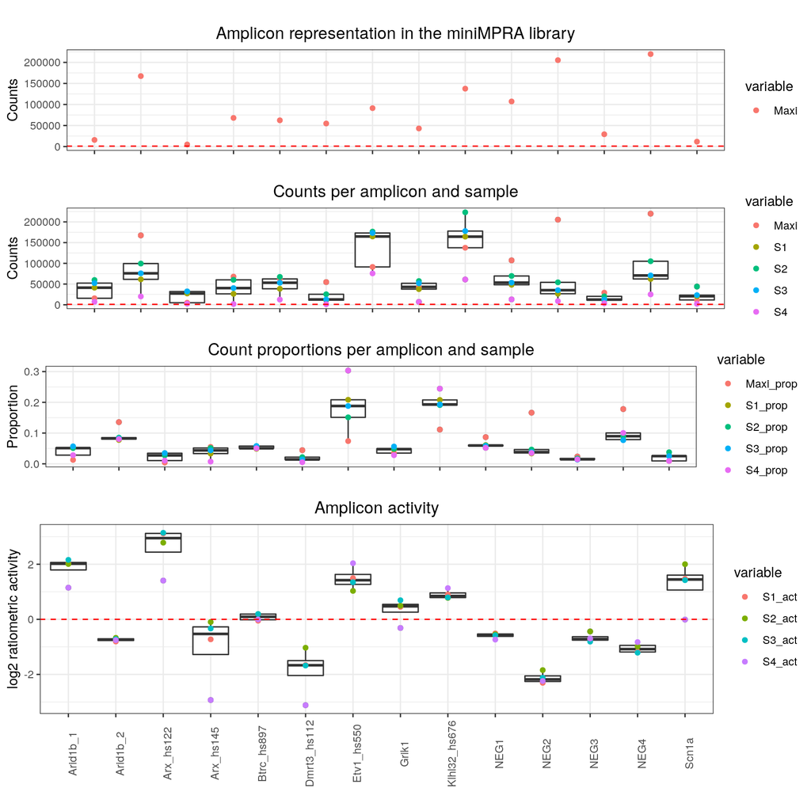

```r
lay <- rbind(c(1),
            c(2),
            c(3),
            c(4),
            c(4))

marrangeGrob(list(p_maxi_counts, p_sample_counts, p_sample_prop, p_sample_act), nrow=4, ncol=1, top = "", layout_matrix = lay)
```

# 4. miniMPRA orthologs vs STAR408

```r
# Removing Chic2_hs687 due to lowe representation in the library
star_mini_MPRA <- star_mini_MPRA[star_mini_MPRA$miniMPRA_ID != "Chic2_hs687",]
star_mini_MPRA <- star_mini_MPRA[star_mini_MPRA$miniMPRA_ID != "Arid1b_3",]

#sum(star_mini_MPRA$Pass_prop_DNA_and_RNA & star_mini_MPRA$Pass_DNA_count) # 8 amplicons
#sum(star408$Pass_prop_DNA_and_RNA & star408$Pass_DNA_count) #309 amplicons

formula <- y ~ x

star_mini_MPRA$Pass_prop_DNA_and_RNA <- ifelse(star_mini_MPRA$RNA_prop_mean > 2^-15 &
                                         star_mini_MPRA$DNA_prop_mean > 2^-15, TRUE, FALSE)

star_mini_MPRA$Pass_DNA_count <- rowSums(star_mini_MPRA[,c(35:38)] > 200) >= 4


star_mini_MPRA$Pass_QC <- ifelse(star_mini_MPRA$Pass_prop_DNA_and_RNA == TRUE & star_mini_MPRA$Pass_DNA_count == TRUE, TRUE, FALSE)

star_mini_MPRA_QC_Passed <- dplyr::filter(star_mini_MPRA, Pass_QC == TRUE)

# Ratiometric STAR408 activity

# act_m_QC_Passed <- dplyr::filter(act_m, miniMPRA_ID %in%  star_mini_MPRA_QC_Passed$miniMPRA_ID)
act_m_QC_Passed <- act_m  # Alex requested to show 14 amplicons passing miniMPRA QC

# Order amplicons by mean activity

mean_miniMPRA_act <- act_m_QC_Passed %>%
  group_by(miniMPRA_ID) %>%
  summarise(average = mean(value))

mean_miniMPRA_act <- as.data.frame(mean_miniMPRA_act)

mean_miniMPRA_act <- arrange(mean_miniMPRA_act, average)
act_m_QC_Passed$miniMPRA_ID <- factor(act_m_QC_Passed$miniMPRA_ID, levels = mean_miniMPRA_act$miniMPRA_ID)

act_m_QC_Passed$variable2 <- ifelse(act_m_QC_Passed$variable == "S1_act", "Sample 1", "")
act_m_QC_Passed$variable2 <- ifelse(act_m_QC_Passed$variable == "S2_act", "Sample 2", act_m_QC_Passed$variable2)
act_m_QC_Passed$variable2 <- ifelse(act_m_QC_Passed$variable == "S3_act", "Sample 3", act_m_QC_Passed$variable2)
act_m_QC_Passed$variable2 <- ifelse(act_m_QC_Passed$variable == "S4_act", "Sample 4", act_m_QC_Passed$variable2)


p_sample_act_figure <- ggplot()+
  geom_hline(yintercept = 0, linetype = 2, color = "black")+
  geom_boxplot(data = act_m_QC_Passed, aes(x = miniMPRA_ID, y = log2(value)), outlier.shape = NA)+
  geom_jitter(data = act_m_QC_Passed, aes(x = miniMPRA_ID, y = log2(value)), width = 0.25, size = 1, alpha = 0.5)+
  theme_bw()+
  labs(x = "", y = "log2 ratiometric activity", title = "miniMPRA activity")+
  theme(plot.title = element_text(hjust = 0.5, size = 14))+
  theme(axis.text.x = element_text(angle = 90))+
  theme(
    text = element_text(size = 12),
    panel.grid.major = element_blank(),
    panel.grid.minor = element_blank(),
    legend.title = element_blank())

#p_sample_act_figure

amplicons_308_minied <- dplyr::filter(amplicons_308, Amp_name2 %in% c("252_PutEnh", "253_PutEnh", "255_PutEnh", "257_PutEnh", "258_PutEnh", "259_PutEnh", "264_PutEnh", "266_PutEnh"))

#filter(amplicons_308_minied, Pvalue < 0.05)$Amp_name


star_mini_MPRA_QC_Passed$Pvalue_sig <- ifelse(star_mini_MPRA_QC_Passed$Amp_name %in% c("252_Control_Arid1b_1", "259_Control_Scn1a"), "P < 0.05", "P > 0.05")


### miniMPRA vs STAR408 correlation
corr_plot <- ggplot(star_mini_MPRA_QC_Passed, aes(x = log2(Mean_act), y = log2(miniMPRA_mean_act)))+
  geom_vline(xintercept = 0, linetype = 2, color = "black")+
  geom_hline(yintercept = 0, linetype = 2, color = "black")+
  geom_smooth(formula = formula, method = 'lm', color = "grey", se = FALSE)+
  geom_point(alpha = 0.5, aes(color = Pvalue_sig), size = 2)+
  geom_text_repel(aes(label = miniMPRA_ID), size = 4)+
  stat_poly_eq(formula = formula,
               aes(label = paste(..rr.label.., sep = "~~~")),
               parse = TRUE, size = 4)+
  labs(x = "log2 STAR408 ratiometric activity",
       y = " log2 miniMPRA activity",
       title = "Human STAR408 vs mouse miniMPRA orthologs",
       color='STAR408 Pvalue')+
  theme_bw()+
  theme(plot.title = element_text(hjust = 0.5, size = 14),
        panel.grid.major = element_blank(),
        panel.grid.minor = element_blank(),
        text = element_text(size = 12),
        plot.margin = margin(t = 0, r = 0, b = 0, l = 20, unit = "pt"),
        legend.position="bottom")+
  scale_color_manual(values = c("red", "black"))

#corr_plot


p1 <- corr_plot
p2 <- p_sample_act_figure


#ggsave("G:/Shared drives/Nord Lab - Temp Overflow/STARR-408_Lambert&Su-Feher/Draft #Figures/Figures_eLIFE_KC/Fig_2EF.png", ggarrange(p2, p1, widths = c(1,1), newpage = FALSE), width = 8, height = #4, dpi = 300, units = "in")


#ggsave("G:/Shared drives/Nord Lab - Temp Overflow/STARR-408_Lambert&Su-Feher/Draft #Figures/Figures_eLIFE_KC/Fig_2EF.svg", ggarrange(p2, p1, widths = c(1,1), newpage = FALSE), width = 8, height = #4, dpi = 300, units = "in")

#save.image("G:/Shared drives/Nord Lab - Computational Projects/MPRA/mini_MPRA/mini_MPRA.RData")
#load("G:/Shared drives/Nord Lab - Computational Projects/MPRA/mini_MPRA/mini_MPRA.RData")
```

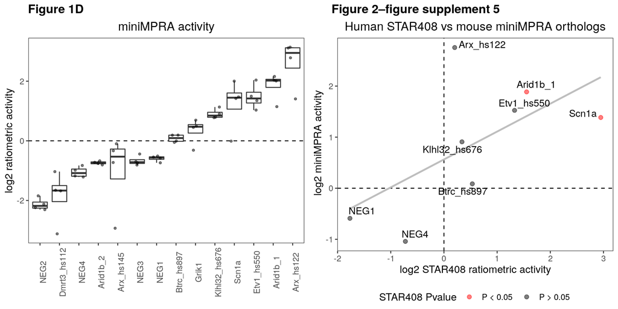

```r
#grid.arrange(p1, p2, nrow = 1, widths = c(1.2, 1))

library(cowplot)

plot_grid(p2 + theme(plot.margin = unit(c(25.5, 5.5, 0, 5.5), units = "pt")),
          p1 + theme(plot.margin = unit(c(25.5, 5.5, 0, 5.5), units = "pt")),
          labels = c('Figure 1D', 'Figure 2–figure supplement 5'),
          label_x = c(0, -0.2),
          vjust = 1.5)
```